# projet.Rmd

Eric

21 janvier 2019

# 1 ETAPE 1

```r
setwd = (".")
getwd()
```

```
## [1] "C:/Users/Eric/Desktop/Biostat/Github/stageL3_2018/Eric"
```

## 1.1 LECTURE DES JEUX DE DONNEE

```r
donnee1 = read.csv (file = "./../data/placenta_edragon_91mol.csv", header = T, sep = ";", dec = ".")
donnee2 = read.csv (file = "./../data/placenta_MOE_2D_192.csv", header = T, dec = ".", sep =";")
```

## 1.2 ON VERIFIE SI LES NOMS DES LIGNES SONT CORRECTES

```r
nom_col1 = donnee1[,"NOM"]
nom_col2 = donnee2[, "Noms"]
comp = nom_col1%in%nom_col2
comp
```

```
##  [1] TRUE TRUE TRUE TRUE TRUE TRUE TRUE TRUE TRUE TRUE TRUE TRUE TRUE TRUE
## [15] TRUE TRUE TRUE TRUE TRUE TRUE TRUE TRUE TRUE TRUE TRUE TRUE TRUE TRUE
## [29] TRUE TRUE TRUE TRUE TRUE TRUE TRUE TRUE TRUE TRUE TRUE TRUE TRUE TRUE
## [43] TRUE TRUE TRUE TRUE TRUE TRUE TRUE TRUE TRUE TRUE TRUE TRUE TRUE TRUE
## [57] TRUE TRUE TRUE TRUE TRUE TRUE TRUE TRUE TRUE TRUE TRUE TRUE TRUE TRUE
## [71] TRUE TRUE TRUE TRUE TRUE TRUE TRUE TRUE TRUE TRUE TRUE TRUE TRUE TRUE
## [85] TRUE TRUE TRUE TRUE TRUE TRUE TRUE
```

**NON**, `%in%` vérifie que ce sont les mêmes nom, mais pas l’ordre or les deux sont importants. En effet, pour vérifier, tu peux essayer :

```r
nom_col2 <- sort(nom_col2, decreasing=T)
comp = nom_col1%in%nom_col2
comp
```

ce qui donne un vecteur Ã `TRUE` aussi. Ce n’est donc pas la bonne fonction.

=> on laisse tomber pour l’instant.

## 1.3 ON INSERE LA DONNEE CLAIRANCE DANS LE FICHIER EDRAGON

```r
clairance = donnee2[,"CI"]
donneefin = data.frame(donnee1, clairance)
```

## 1.4 DIMENSION DE LA TABLE

```r
dim(donneefin)
```

```
## [1]  91 801
```

-> Les dimensions de la table sont 801 descripteurs et 91 composÃ©s.

## 1.5 LES ENTETES DES LIGNES

```r
namecol = colnames(donneefin)
```

-> On enleve les 2 premières colonnes (NOMS et ID)

```r
donneefin = donneefin[ ,-c(1:2)]
```

# 2 ETAPE 2

## 2.1 VALEURS ABERRANTES DANS CI

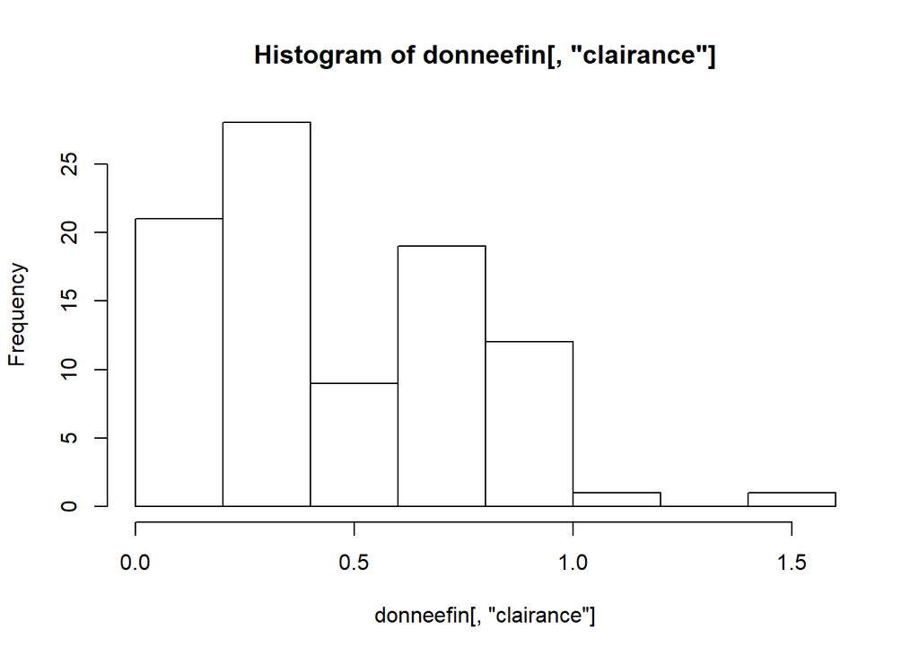

```r
hist(donneefin[, "clairance"])
```

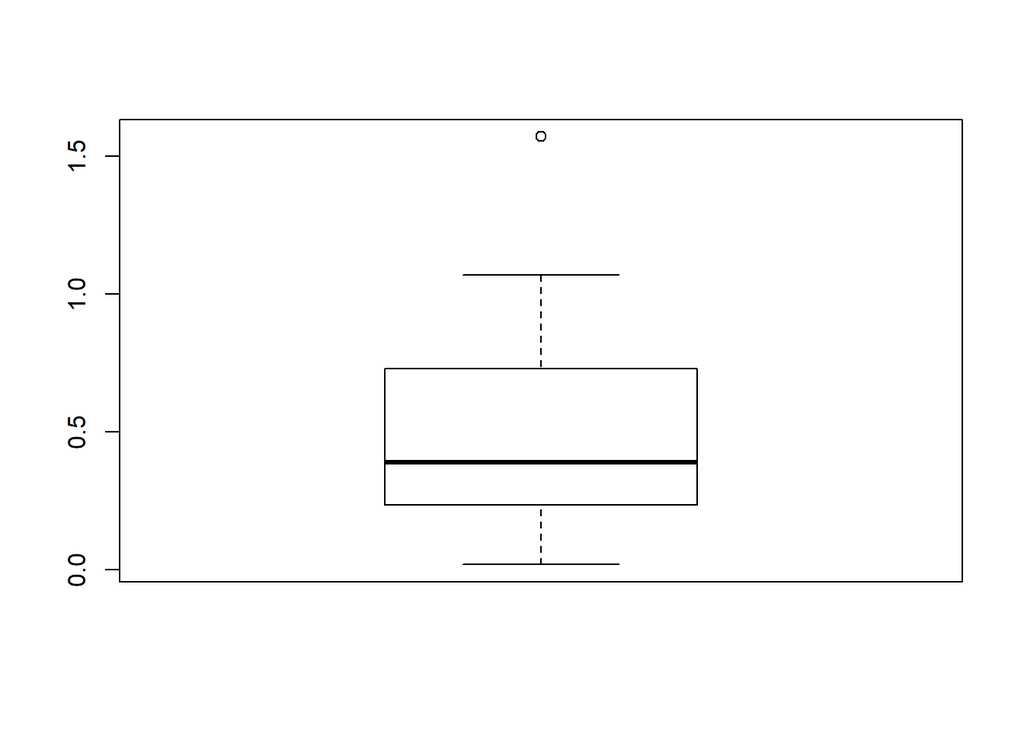

```r
box = boxplot (donneefin [,"clairance"])
```

```r
box
```

```
## $stats
##       [,1]
## [1,] 0.020
## [2,] 0.235
## [3,] 0.390
## [4,] 0.730
## [5,] 1.070
##
## $n
## [1] 91
##
## $conf
##           [,1]
## [1,] 0.3080136
## [2,] 0.4719864
##
## $out
## [1] 1.57
##
## $group
## [1] 1
##
## $names
## [1] "1"
```

```r
boxmax = box$out
```

On remarque une valeur aberrante (1,57) On extrait la valeur dans boxmax

-> On transforme le 1.57 en NA

```r
donneefin$clairance[donneefin$clairance == boxmax] <- NA
```

-> On supprime les NA

```r
donneefin = na.omit(donneefin)
donneefin$clairance
```

```
##  [1] 0.47 0.25 0.17 0.30 0.75 0.47 0.38 0.29 0.41 0.35 0.72 0.73 0.29 0.04
## [15] 0.20 0.12 0.83 0.30 0.06 0.78 0.88 0.50 0.74 0.31 0.61 0.37 0.98 0.79
## [29] 0.31 1.07 0.10 0.17 0.26 0.61 0.39 0.72 0.80 0.95 0.23 0.62 0.91 0.73
## [43] 0.35 0.08 0.40 0.34 0.83 0.14 0.63 0.64 0.93 0.13 0.07 0.74 0.04 0.52
## [57] 0.52 0.38 0.51 0.37 0.07 0.56 1.00 0.69 0.37 0.12 0.10 0.09 0.75 0.20
## [71] 0.40 0.05 0.39 0.31 0.24 0.66 0.47 0.81 0.80 0.95 0.04 0.85 0.19 0.32
## [85] 0.95 0.31 0.22 0.28 0.26 0.02
```

## 2.2 DONNEE MANQUANTE (-999)

-> On compte le nombre de -999

### 2.2.1 Methode 1: Sans convertir -999 en NA

```r
suma = apply(donneefin, 2, function(x) sum(x==-999))
```

-> On supprimme les colonnes ne contenant que des -999 ()

```r
donneefin2 = Filter(function(x) length(unique(x))>1, donneefin)
```

### 2.2.2 Methode 2: On remplace les -999 par NA

```r
donneefin[donneefin == -999] <- NA
```

-> On compte le nombre de NA dans chaque colonne et on enleve les colonnes ayant des NA

```r
sum_NA = apply (donneefin, 2, function(x) sum (is.na(x)))

sum_non_NA = which(sum_NA ==0)

donneefin = donneefin[ ,sum_non_NA]
```

3. DONNEE CONSTANTES

-> On calcul la variance de chaque colonne et on ne garde que les colonnes qui ont une variance superieure à 0

```r
varx = apply(donneefin[,1:780], MARGIN = 2, FUN = var)

toRm = which(varx == 0)
toKeep = which(varx > 0)
donneefinbis = donneefin[,toKeep]
```

# 3 Sauvegarde des donnÃ©es

`write.table` Ã©crire au format texte `save`sauvegarder au format .Rdata, (`load`)